# The effect of nursing home status on hospitalisation: A toy example

Hristo Inouzhe

2024-05-20

# Introduction

This is a short tutorial based on the article Inouzhe et al. (2023). Our main goal is for the reader to be able to apply the methods to their own data. Hence, we provide all the necessary tools with meaningful examples.

We start by requiring libraries and sourcing functions:

```r
require(dplyr)
require(transport)
require(ggplot2)
require(reshape2)
require(cubature)
require(ks)
require(MatchIt)
source("Functions/totalVariationAnalysis.R")
source("Functions/weightedMeansDifference.R")
source("Functions/wasserDistance.R")
```

Since data protection restrict us from using the data in Inouzhe et al. (2023) we use a synthetic dataset generated artificially to imitate the data, where the covariates of interest are $\mathbf{X}=\{age, Charlson\_index, time\_to\_positive, dementia\}$, the treatment variable $Z$ is $nursing\_home$ and the output variable $Y$ is hospitalisation.

```r
dataNursingHomes <- read.csv("Data/nursing_home_synthetic.csv")
head(dataNursingHomes)
```

```
##   age Charlson_index time_to_positive dementia nursing_home hospitalisation
## 1  65             16               39        0            0               1
## 2  78             10               29        0            0               1
## 3  81             15               24        0            0               1
## 4  75              8               26        0            0               1
## 5  99             18               12        0            0               1
## 6  75             14               39        0            0               1
```

# Matching with Euclidean distance

To perform a matching based on the (squared) Euclidean distance we compute it, where we also make a normalisation to equiparate the different variables

```r
dist.Euclidean <- as.matrix(dist(cbind((dataNursingHomes$age - 60) / (105 - 60),
                                            dataNursingHomes$Charlson_index / 20,
                                            dataNursingHomes$time_to_positive / 121,
                                            dataNursingHomes$dementia
))^2)
```

The matching procedure is based on solving approximately a 1-to-1 optimal matching problem, where the approximation is based on nearest neighbours. More info can be found in Ho et al. (2011).

```r
# We create the model for matching, where we match nursing home residents and
# non-residents with respect to the four confounders of interest
formula_obj <- as.formula("nursing_home ~ age + `Charlson_index` + `time_to_positive` + `dementia`")

# We use 1-to-1 optimal matching by the nearest-neighbour approximation in the MatchIt package
MatchIt.euc.nearest <- MatchIt::matchit(formula_obj,
                                          data = dataNursingHomes,
                                          method = "nearest",
                                          distance = dist.Euclidean)
```

# Matching with propensity distance

The Euclidean distance in the original attributes is just one possible choice. A popular one is to use distance in propensity score $e(\mathbf{X})=E(Z|\mathbf(X))$. To estimate the conditional expectation we used Python and provide a Jupyter Lab Notebook as the companion file Sensitivity_Analysis-toy_example.ipynb (titled Propensity score estimation and Sensitivity Analysis for bias in Nursing Homes).

We just load the propensity score, define a distance matrix based on it and compute the corresponding inverse weights.

```r
# Load propensity computed with python

propensity <- read.table("Data/propensity_period_1_toy.csv",
                                  quote="\"", comment.char="")

# Computation of the distance matrix based on propensity scores

dist.propensity <- as.matrix(dist(propensity))

# Inverse Propensity Weights
weight.g.propensity <- dataNursingHomes$nursing_home / propensity +
  (1 - dataNursingHomes$nursing_home) / (1 - propensity)

# Propensity Weights
weight.ATO <- (1 - propensity) * dataNursingHomes$nursing_home + propensity * (1 - dataNursingHomes$nursing_home)
```

After that, as for the Euclidean case, we compute the matched samples.

```r
MatchIt.propensity.nearest <- MatchIt::matchit(formula_obj,
                                               data = dataNursingHomes,
                                               method = "nearest",
                                               distance = dist.propensity)
```

# Average Treatment Effect (ATE) estimates

With the previous weighted subsamples and some alternative estimates obtained in Propensity score estimation and Sensitivity Analysis for bias in Nursing Homes one obtains the following ATEs.

```r
ate.table <- array(dim = c(7,2))
ate.python <- read.csv("Data/ate_python.csv", header = FALSE, sep = ",")

# Naif approximation (as if data come from a randomized study)
ate.table[1, ] <- as.numeric(weightedMeansDifference(subset(dataNursingHomes, nursing_home == 0)$hospitalisation,
                      subset(dataNursingHomes, nursing_home == 1)$hospitalisation,
                      rep(1, sum(dataNursingHomes$nursing_home == 0)),
                      rep(1, sum(dataNursingHomes$nursing_home == 1))))

# Estimates assuming observational data

# Estimation from adjustment formula
ate.table[2, ] <- as.numeric(ate.python[1, ])

# Estimation using matching with squared Euclidean distance
ate.table[3,] <- as.numeric(weightedMeansDifference(dataNursingHomes$hospitalisation[as.numeric(MatchIt.euc.nearest$match.matrix)],
                      subset(dataNursingHomes, nursing_home == 1)$hospitalisation,
                      rep(1, length(as.numeric(MatchIt.euc.nearest$match.matrix))),
                      rep(1, sum(dataNursingHomes$nursing_home == 1))))

# Estimation using matching with squared Propensity distance
ate.table[4, ] <- as.numeric(weightedMeansDifference(dataNursingHomes$hospitalisation[as.numeric(MatchIt.propensity.nearest$match.matrix)],
                      subset(dataNursingHomes, nursing_home == 1)$hospitalisation,
                      rep(1, length(as.numeric(MatchIt.propensity.nearest$match.matrix))),
                      rep(1, sum(dataNursingHomes$nursing_home == 1))))

# Estimation using a doubly robust estimator
ate.table[5, ] <- as.numeric(ate.python[2, ])

# The classical classical estimator based on inverse propensity weighting
ate.table[6, ] <- as.numeric(ate.python[3, ])

# An estimator based on propensity weighting, usually known as Average Treatment on the Overlap (ATO)
ate.table[7, ] <- as.numeric(weightedMeansDifference(subset(dataNursingHomes, nursing_home == 0)$hospitalisation,
                      subset(dataNursingHomes, nursing_home == 1)$hospitalisation,
                      weight.ATO$V1[which(dataNursingHomes$nursing_home == 0)],
                      weight.ATO$V1[which(dataNursingHomes$nursing_home == 1)]))
colnames(ate.table) <- c("ATE", "Plus-minus")
rownames(ate.table) <- c("Naif", "Adjustment Formula", "Matched Euc", "Matched Propensity",
                                     "Inverse Prop Weighting Doubly Robust", "Inverse Prop Weighting", "Propensity Weighted")
ate.table
```

```
##                                             ATE Plus-minus
## Naif                                 -0.5516484 0.05147855
## Adjustment Formula                   -0.3520615 0.01402976
## Matched Euc                          -0.5514286 0.06093597
## Matched Propensity                   -0.4457143 0.06373597
## Inverse Prop Weighting Doubly Robust -0.3118251 0.04904907
## Inverse Prop Weighting               -0.4646313 0.06922174
## Propensity Weighted                  -0.4150567 0.07122423
```

# ATE estimates quality diagnostics

To check the good behaviour of the ATE estimates used in the previous section we need to rely on some diagnostic procedures.

## Porpensity score distributions

A first one is to visually compare the distributions of the propensity scores estimates for each class, nursing home residents (Z=1) and non-residents (Z=0), for all the esimates.

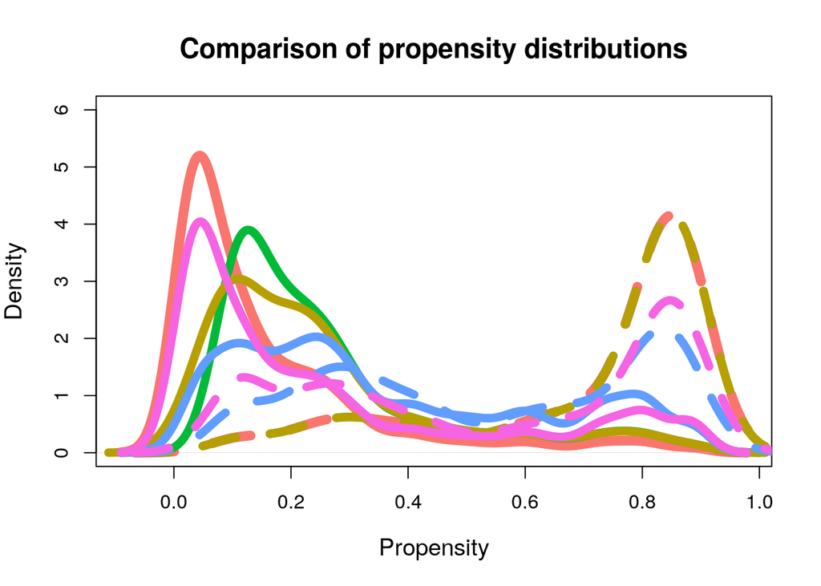

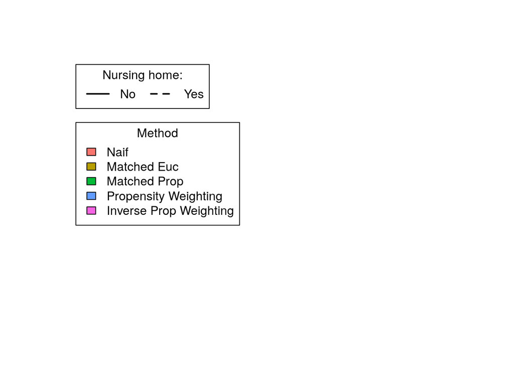

```r
plot(density(propensity$V1[which(dataNursingHomes$nursing_home == 0)]),
     main = "Comparison of propensity distributions",
     xlab = "Propensity", ylim = c(0, 6), col = "#F8766D", lwd = 8,
     cex.main = 1.4, cex.axis = 1, cex.lab = 1.2)
lines(density(propensity$V1[which(dataNursingHomes$nursing_home == 1)]), lty = 2, col = "#F8766D", lwd = 8)
lines(density(propensity$V1[as.numeric(MatchIt.propensity.nearest$match.matrix)]),
      col = "#00BA38", lwd = 7)
lines(density(propensity$V1[which(dataNursingHomes$nursing_home == 1)]),
      col = "#00BA38", lty = 2, lwd = 7)
lines(density(propensity$V1[as.numeric(MatchIt.euc.nearest$match.matrix)]),
      col = "#B79F00", lwd = 7)
lines(density(propensity$V1[which(dataNursingHomes$nursing_home == 1)]),
      col = "#B79F00", lty = 2, lwd = 7)
lines(density(propensity$V1[dataNursingHomes$nursing_home == 0],
              weights =  weight.ATO$V1[dataNursingHomes$nursing_home == 0] /
                sum(weight.ATO$V1[dataNursingHomes$nursing_home == 0])),
      col = "#619CFF", lwd = 7)
lines(density(propensity$V1[dataNursingHomes$nursing_home == 1],
              weights = weight.ATO$V1[dataNursingHomes$nursing_home == 1] /
                sum(weight.ATO$V1[dataNursingHomes$nursing_home == 1])),
      col = "#619CFF", lty = 2, lwd = 7)
lines(density(propensity$V1[dataNursingHomes$nursing_home == 0],
              weights = weight.g.propensity$V1[dataNursingHomes$nursing_home == 0] /
                sum(weight.g.propensity$V1[dataNursingHomes$nursing_home == 0])),
      col = "#F564E3", lwd = 7)
lines(density(propensity$V1[dataNursingHomes$nursing_home == 1],
              weights = weight.g.propensity$V1[dataNursingHomes$nursing_home == 1] /
                sum(weight.g.propensity$V1[dataNursingHomes$nursing_home == 1])),
      col = "#F564E3", lty = 2,lwd = 7)
```

Clearly we see that all methods are producing propensity distributions that are more similar than the original ones in red.

## Total Variation distance (TVd) on the marginals

Another possibility is to compare the marginal distributions on the original variables. We chose to this using the well known Total Varaition distance. The wrapper function, totalVariationAnalysis, estimates the 1D TVd’s for discrete and continuous variables. Bellow are the examples for the corresponding ATEs.

```r
vars_of_interest = names(dataNursingHomes)[1:4]
total.variation.0 <- totalVariationAnalysis(vars = vars_of_interest, data = dataNursingHomes,
                                                        strata = "nursing_home", strata.levels = c(0, 1),
                                                        vars_cont = c("age", "time_to_positive"))
total.variation.euc.1 <- totalVariationAnalysis(vars = vars_of_interest,
                                                data = dataNursingHomes[c(as.numeric(MatchIt.euc.nearest$match.matrix),
                                                                          which(dataNursingHomes[["nursing_home"]] == 1)), ],
                                                        strata = "nursing_home", strata.levels = c(0, 1),
                                                        vars_cont = c("age", "time_to_positive"))
```

```r
total.variation.prop.0 <- totalVariationAnalysis(vars = vars_of_interest, data = dataNursingHomes,
                                                        strata = "nursing_home", strata.levels = c(0, 1),
                                                        vars_cont = c("age", "time_to_positive"),
                                                 weights.g = weight.g.propensity$V1)
total.variation.prop.1 <- totalVariationAnalysis(vars = vars_of_interest, data =
                                                   dataNursingHomes[c(as.numeric(MatchIt.propensity.nearest$match.matrix),
                                                                      which(dataNursingHomes[["nursing_home"]] == 1)), ],
                                                        strata = "nursing_home", strata.levels = c(0, 1),
                                                        vars_cont = c("age", "time_to_positive"))
total.variation.prop.2 <- totalVariationAnalysis(vars = vars_of_interest, data = dataNursingHomes,
                                                        strata = "nursing_home", strata.levels = c(0, 1),
                                                        vars_cont = c("age", "time_to_positive"),
                                                 weights.g = weight.ATO$V1)
```

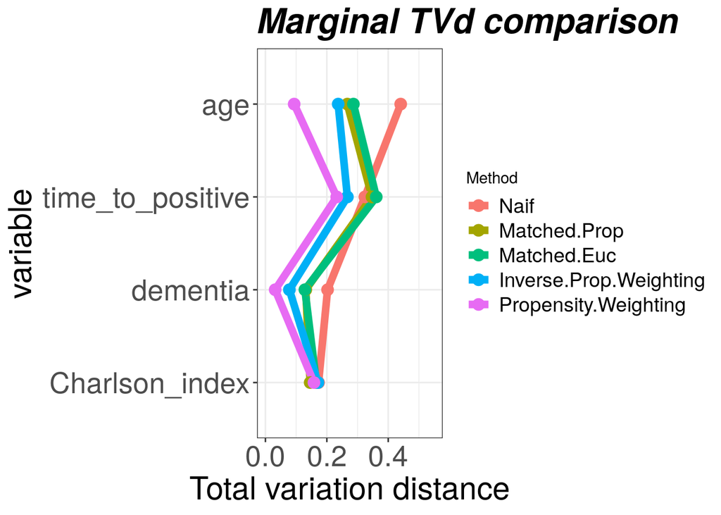

```r
dataPlot <- data.frame(variable   =  vars_of_interest,
                       Naif  = total.variation.0,
                       "Matched Prop"   = total.variation.prop.1,
                       "Matched Euc"   = total.variation.euc.1,
                       "Inverse Prop Weighting" = total.variation.prop.0,
                       "Propensity Weighting" = total.variation.prop.2
)
dataPlot_Melt <- melt(data          = dataPlot,
                      id.vars       = c("variable"),
                      variable.name = "Method",
                      value.name    = "Total variation distance")
varNames <- as.character(dataPlot$variable)[order(dataPlot$Naif)]
dataPlot_Melt$variable <- factor(dataPlot_Melt$variable,
                                 levels = varNames)

ggplot(data = dataPlot_Melt,
       mapping = aes(x = variable, y = `Total variation distance`, group = Method, color = Method)) +
  geom_line(size = 2.5) +
  geom_point(size = 3.5) +
  coord_flip(ylim = c(0, 0.55)) +
  theme_bw() +
  ggtitle ("Marginal TVd comparison") +
  theme(plot.title = element_text(color="black", size=24, face="bold.italic"),
        legend.key = element_blank(),
        axis.text=element_text(size=20),
        axis.title=element_text(size=22),
        legend.text = element_text(size=14))
```

## Multivariate similarity

It is well known that similarity in marginals does not guarantee similarity in the multivariate space. Here we use an approache based on the $d-$Wasserstein distance, which allows weighted data. Details are provided in Inouzhe et al. (2023).

We start with a particular normalisation of the data.

```r
dataNursingHomesNorm <- dataNursingHomes[, 1:5]
dataNursingHomesNorm[, 1] <- (dataNursingHomesNorm[, 1] - 60) / (105 - 60)
dataNursingHomesNorm[, 2] <- dataNursingHomesNorm[, 1] / 20
dataNursingHomesNorm[, 3] <- dataNursingHomesNorm[, 1] / 121
```

Then we compute the 2-Wasserstein distance for the weighed (sub)samples.

```r
period.1.stats.wasser <- array(dim = c(5, 1))
dist.matrix <- as.matrix(dist(dataNursingHomesNorm[,-dim(dataNursingHomesNorm)[2]]))

# 2-Wasserstein distance for the original data corresponding to the Naif estimator
n.A <- sum(dataNursingHomesNorm$nursing_home == 0)
n.B <- sum(dataNursingHomesNorm$nursing_home == 1)
A.1 <- rep(1/n.A, n.A)
B.1 <- rep(1/n.B, n.B)

period.1.stats.wasser[1, ] <- wasserDistance(A.1, B.1,
                                           (dist.matrix[which(dataNursingHomesNorm$nursing_home == 0),
                                                          which(dataNursingHomesNorm$nursing_home == 1)])^2,
                                           2)
# 2-Wasserstein distance for the data matched using the Euclidean distance
n.A <- length(as.numeric(MatchIt.euc.nearest$match.matrix))
A.1 <- rep(1/n.A, n.A)
period.1.stats.wasser[2, ] <- wasserDistance(A.1, B.1,
                                           (dist.matrix[as.numeric(MatchIt.euc.nearest$match.matrix),
                                                        which(dataNursingHomes[["nursing_home"]] == 1)])^2,
                                           2)
# 2-Wasserstein distance for the data matched using the Propensity distance
n.A <- length(as.numeric(MatchIt.propensity.nearest$match.matrix))
A.1 <- rep(1/n.A, n.A)
period.1.stats.wasser[3, ] <- wasserDistance(A.1, B.1,
                                           (dist.matrix[as.numeric(MatchIt.propensity.nearest$match.matrix),
                                                        which(dataNursingHomes[["nursing_home"]] == 1)])^2,
                                           2)
# 2-Wasserstein distance for the data weighted using Inverse Propensity Weighting
A.1 <- weight.g.propensity[which(dataNursingHomesNorm$nursing_home == 0), 1]
A.1 <- A.1 / sum(A.1)
B.1 <- weight.g.propensity[which(dataNursingHomesNorm$nursing_home == 1), 1]
B.1 <- B.1 / sum(B.1)
period.1.stats.wasser[4, ] <- wasserDistance(A.1, B.1,
                                           (dist.matrix[which(dataNursingHomesNorm$nursing_home == 0),
                                                          which(dataNursingHomesNorm$nursing_home == 1)])^2,
                                           2)
# 2-Wasserstein distance for the data weighted using Propensity Weighting
A.1 <- weight.ATO[which(dataNursingHomesNorm$nursing_home == 0), 1]
A.1 <- A.1 / sum(A.1)
B.1 <- weight.ATO[which(dataNursingHomesNorm$nursing_home == 1), 1]
B.1 <- B.1 / sum(B.1)
period.1.stats.wasser[5, ] <- wasserDistance(A.1, B.1,
                                           (dist.matrix[which(dataNursingHomesNorm$nursing_home == 0),
                                                          which(dataNursingHomesNorm$nursing_home == 1)])^2,
                                           2)
rownames(period.1.stats.wasser) <- c("Naif", "Matched Euc", "Matched Prop", "Inverse Prop Weighting", "Propensity Weighting")
colnames(period.1.stats.wasser) <- c("2-Wasserstein")
period.1.stats.wasser
```

```
##                        2-Wasserstein
## Naif                       0.5451228
## Matched Euc                0.3846015
## Matched Prop               0.3938289
## Inverse Prop Weighting     0.3286053
## Propensity Weighting       0.1892757
```

# Conclusions

In this fictitious example, the ATE estimates show that there is strong discrimination against nursing home residents, since they are much lees likely to be hospitalised than their non-residents counterparts. However, one must be cautious because of residual confounding due to joint distributions not being exactly the same and due to unobserved confounding (also known as omitted variable bias). The latter is quantified with the methods presented in Veitch and Zaveri (2020) in Propensity score estimation and Sensitivity Analysis for bias in Nursing Homes.

# References

Ho, D., K. Imai, G. King, and E. Stuart. 2011. “MatchIt: Nonparametric Preprocessing for Parametric Causal Inference.” https://www.jstatsoft.org/article/view/v042i08.

Inouzhe, Hristo, Irantzu Barrio, María Xosé Rodríguez-Álvarez, Paula Gordaliza, Itxaso Bengoechea, and José María Quintana. 2023. “A Study on Group Fairness in Healthcare Outcomes for Nursing Home Residents During the COVID-19 Pandemic in the Basque Country.” https://arxiv.org/abs.

Veitch, Victor, and Anisha Zaveri. 2020. “Sense and Sensitivity Analysis: Simple Post-Hoc Analysis of Bias Due to Unobserved Confounding.” https://arxiv.org/abs/2003.01747.